# Predicting How Well Health Participants Perform Weight Lifting Exercises

17/11/2014

### Introduction:

In this report, I will try to build a machine learning model to predict how well health participants perform weight lifting exercises based on a publicly available Weight Lifting Exercises Dataset. In particular, I will describe:

- How I built my model, including how I selected the important attributes for prediction.
- How I used Cross Validation.
- How I evaluated my model based on a testing sample of the data.

### Data:

Six male participants aged between 20-28 years were asked to perform one set of 10 repetitions of the Unilateral Dumbbell Biceps Curl in five different fashions:

- exactly according to the specification (Class A)
- throwing the elbows to the front (Class B)
- lifting the dumbbell only halfway (Class C)
- lowering the dumbbell only halfway (Class D)
- throwing the hips to the front (Class E)

#### Citation:

The Weight Lifting Exercises Dataset is available from the following source:

**Velloso, E.; Bulling, A.; Gellersen, H.; Ugulino, W.; Fuks, H. Qualitative Activity Recognition of Weight Lifting Exercises. Proceedings of 4th International Conference in Cooperation with SIGCHI (Augmented Human ’13) . Stuttgart, Germany: ACM SIGCHI, 2013.**

URL: **http://groupware.les.inf.puc-rio.br/har#ixzz3JtVWwoJt**

#### Cases:

```r
cases <- dim(mydata)[1]
vars <- dim(mydata)[2]
```

There are 19622 cases representing the exercise events of the participants.

#### Variables:

There are 160 variables in the dataset.

##### Predictors

```r
options(width = 300)
names(mydata[-c(1,2,160)])
```

```
  [1] "raw_timestamp_part_1"     "raw_timestamp_part_2"     "cvtd_timestamp"           "new_window"               "num_window"               "roll_belt"                "pitch_belt"               "yaw_belt"                 "total_accel_belt"         "kurtosis_roll_belt"
 [11] "kurtosis_picth_belt"      "kurtosis_yaw_belt"        "skewness_roll_belt"       "skewness_roll_belt.1"     "skewness_yaw_belt"        "max_roll_belt"            "max_picth_belt"           "max_yaw_belt"             "min_roll_belt"            "min_pitch_belt"
 [21] "min_yaw_belt"             "amplitude_roll_belt"      "amplitude_pitch_belt"     "amplitude_yaw_belt"       "var_total_accel_belt"     "avg_roll_belt"            "stddev_roll_belt"         "var_roll_belt"            "avg_pitch_belt"           "stddev_pitch_belt"
 [31] "var_pitch_belt"           "avg_yaw_belt"             "stddev_yaw_belt"          "var_yaw_belt"             "gyros_belt_x"             "gyros_belt_y"             "gyros_belt_z"             "accel_belt_x"             "accel_belt_y"             "accel_belt_z"
 [41] "magnet_belt_x"            "magnet_belt_y"            "magnet_belt_z"            "roll_arm"                 "pitch_arm"                "yaw_arm"                  "total_accel_arm"          "var_accel_arm"            "avg_roll_arm"             "stddev_roll_arm"
 [51] "var_roll_arm"             "avg_pitch_arm"            "stddev_pitch_arm"         "var_pitch_arm"            "avg_yaw_arm"              "stddev_yaw_arm"           "var_yaw_arm"              "gyros_arm_x"              "gyros_arm_y"              "gyros_arm_z"
 [61] "accel_arm_x"              "accel_arm_y"              "accel_arm_z"              "magnet_arm_x"             "magnet_arm_y"             "magnet_arm_z"             "kurtosis_roll_arm"        "kurtosis_picth_arm"       "kurtosis_yaw_arm"         "skewness_roll_arm"
 [71] "skewness_pitch_arm"       "skewness_yaw_arm"         "max_roll_arm"             "max_picth_arm"            "max_yaw_arm"              "min_roll_arm"             "min_pitch_arm"            "min_yaw_arm"              "amplitude_roll_arm"       "amplitude_pitch_arm"
 [81] "amplitude_yaw_arm"        "roll_dumbbell"            "pitch_dumbbell"           "yaw_dumbbell"             "kurtosis_roll_dumbbell"   "kurtosis_picth_dumbbell"  "kurtosis_yaw_dumbbell"    "skewness_roll_dumbbell"   "skewness_pitch_dumbbell"  "skewness_yaw_dumbbell"
 [91] "max_roll_dumbbell"        "max_picth_dumbbell"       "max_yaw_dumbbell"         "min_roll_dumbbell"        "min_pitch_dumbbell"       "min_yaw_dumbbell"         "amplitude_roll_dumbbell"  "amplitude_pitch_dumbbell" "amplitude_yaw_dumbbell"   "total_accel_dumbbell"
[101] "var_accel_dumbbell"       "avg_roll_dumbbell"        "stddev_roll_dumbbell"     "var_roll_dumbbell"        "avg_pitch_dumbbell"       "stddev_pitch_dumbbell"    "var_pitch_dumbbell"       "avg_yaw_dumbbell"         "stddev_yaw_dumbbell"      "var_yaw_dumbbell"
[111] "gyros_dumbbell_x"         "gyros_dumbbell_y"         "gyros_dumbbell_z"         "accel_dumbbell_x"         "accel_dumbbell_y"         "accel_dumbbell_z"         "magnet_dumbbell_x"        "magnet_dumbbell_y"        "magnet_dumbbell_z"        "roll_forearm"
[121] "pitch_forearm"            "yaw_forearm"              "kurtosis_roll_forearm"    "kurtosis_picth_forearm"   "kurtosis_yaw_forearm"     "skewness_roll_forearm"    "skewness_pitch_forearm"   "skewness_yaw_forearm"     "max_roll_forearm"         "max_picth_forearm"
[131] "max_yaw_forearm"          "min_roll_forearm"         "min_pitch_forearm"        "min_yaw_forearm"          "amplitude_roll_forearm"   "amplitude_pitch_forearm"  "amplitude_yaw_forearm"    "total_accel_forearm"      "var_accel_forearm"        "avg_roll_forearm"
[141] "stddev_roll_forearm"      "var_roll_forearm"         "avg_pitch_forearm"        "stddev_pitch_forearm"     "var_pitch_forearm"        "avg_yaw_forearm"          "stddev_yaw_forearm"       "var_yaw_forearm"          "gyros_forearm_x"          "gyros_forearm_y"
[151] "gyros_forearm_z"          "accel_forearm_x"          "accel_forearm_y"          "accel_forearm_z"          "magnet_forearm_x"         "magnet_forearm_y"         "magnet_forearm_z"
```

##### Target attribute

```r
levels(mydata$classe)
```

```
[1] "A" "B" "C" "D" "E"
```

### Predictive Modelling

I will use the **Random Forest** Classification Algorithm described in **http://www.stat.berkeley.edu/~breiman/RandomForests/cc_home.htm#ooberr** to build a Predictive Model based on the exercise events data to predict the **classe** variable. The reason I chose Random Forest is because:

- It is unexcelled in accuracy among current algorithms.
- It can handle thousands of input variables without variable deletion, which is suitable for our case since we have plenty of input variables.
- It gives estimates of what variables are important in the classification.
- It generates an internal unbiased estimate of the generalization error as the forest building progresses.
- Random forests does not overfit, without the need for explicit cross-validation or a separate test set to get an unbiased estimate of the test set error. It is estimated internally, during the run.

#### Creating Training / Testing Samples

I will have 70% of the original dataset for training the model and use the remaining 30% of the data for evaluating the model.

```r
mydata[,c(3:159)] <- sapply(mydata[,c(3:159)],as.numeric)
set.seed(33833)
inTrain <- createDataPartition(y=mydata$classe, p=0.70, list=FALSE)
training <- mydata[inTrain,]
testing <- mydata[-inTrain,]
tr <- dim(training)[1]
ts <- dim(testing)[1]
```

- Training sample contains 13737 cases.
- Testing sample contains 5885 cases.

#### Variable Importance

Here I will calculate the variable importance. First, I will run random forests with all the variables. Second, I will use the varImp function in the caret package to depict the most important variables that Random Forests used to build the model, based on the Gini Importance.

```r
modFit <- train(classe ~ .,data=training[c(3:160)],method="rf",prox=TRUE)
```

##### Gini importance

```r
varImp(modFit, type=2)
```

```
rf variable importance

  only 20 most important variables shown (out of 157)

                     Overall
min_roll_forearm      100.00
var_accel_dumbbell     63.32
var_roll_belt          55.92
stddev_roll_belt       45.92
raw_timestamp_part_1   35.57
var_total_accel_belt   32.23
avg_roll_dumbbell      30.65
magnet_dumbbell_z      29.62
magnet_dumbbell_y      25.34
avg_roll_belt          22.79
num_window             21.37
avg_roll_forearm       20.98
accel_forearm_z        20.33
avg_pitch_forearm      18.82
roll_dumbbell          18.35
var_accel_arm          17.43
cvtd_timestamp         16.68
amplitude_yaw_arm      16.27
accel_dumbbell_y       10.45
amplitude_pitch_arm     9.76
```

#### Fitting the Model for Prediction

In the next run of Random Forests, I will include only the variables that have no missing values in the accompanying test set having 20 cases. These variables will be the predictors to build my Random Forests model.

```r
mydatatestnomissing <- mydatatest[,colSums(is.na(mydatatest)) != nrow(mydatatest)]
cols <- names(mydatatestnomissing[-c(1,2,60)])
cols[length(cols)+1] <- "classe"
trainingsubset <- training[,cols]
modFit2 <- randomForest(classe ~ ., data=trainingsubset, importance=TRUE, proximity=TRUE)
```

Below is a figure that depicts the attribute importance of the final model:

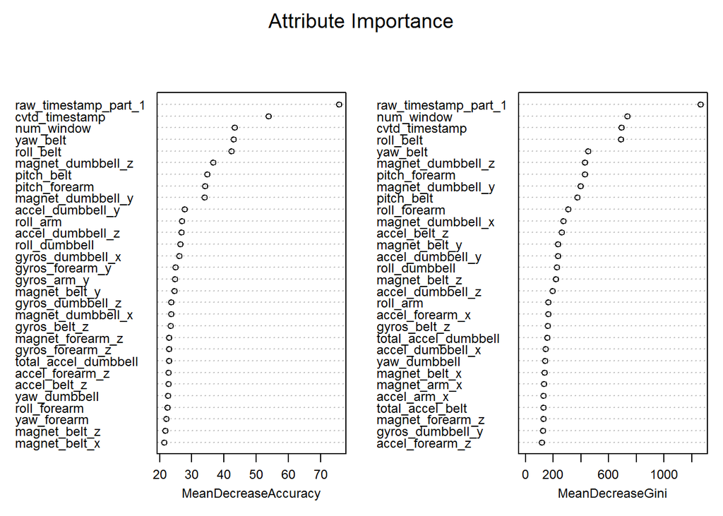

```r
varImpPlot(modFit2, main="Attribute Importance", cex=.75)
```

#### In-Sample and Out-of-Sample Evaluation

##### In-Sample Confusion Matrix

```r
modFit2$confusion
```

```
     A    B    C    D    E class.error
A 3906    0    0    0    0   0.0000000
B    2 2656    0    0    0   0.0007524
C    0    9 2387    0    0   0.0037563
D    0    0    8 2242    2   0.0044405
E    0    0    0    2 2523   0.0007921
```

As can be seen above, the In-Sample class error is very small, showing very good prediction power.

##### Out-of-Sample Confusion Matrix

Here I apply the model on the testing sample and depict the confusion matrix to determine whether my model can generalize to out of sample cases:

```r
testingsubset <- testing[,cols]
pred <- predict(modFit2,testingsubset)
confusionMatrix(pred,testingsubset$classe)
```

```
Confusion Matrix and Statistics

          Reference
Prediction    A    B    C    D    E
         A 1672    0    0    0    0
         B    2 1139    2    0    0
         C    0    0 1024    3    0
         D    0    0    0  960    0
         E    0    0    0    1 1082

Overall Statistics

               Accuracy : 0.999
                 95% CI : (0.997, 0.999)
    No Information Rate : 0.284
    P-Value [Acc > NIR] : <2e-16

                  Kappa : 0.998
 Mcnemar's Test P-Value : NA

Statistics by Class:

                     Class: A Class: B Class: C Class: D Class: E
Sensitivity             0.999    1.000    0.998    0.996    1.000
Specificity             1.000    0.999    0.999    1.000    1.000
Pos Pred Value          1.000    0.997    0.997    1.000    0.999
Neg Pred Value          1.000    1.000    1.000    0.999    1.000
Prevalence              0.284    0.194    0.174    0.164    0.184
Detection Rate          0.284    0.194    0.174    0.163    0.184
Detection Prevalence    0.284    0.194    0.175    0.163    0.184
Balanced Accuracy       0.999    1.000    0.999    0.998    1.000
```

### Conclusion:

As can be seen by the evaluation details based on the out-of-sample cases, the prediction accuracy is very high on all the five classes of the outcome variable. This means the model can generalize to out of sample cases.